# Some Advice for Data Visualization

Muhammad Hilmi Abdul Majid

## Introduction

We have been producing graphs and visuals to represent our data. In this topic, we will focus on giving some advice for data visualization. These are general advice that you may already apply to your work without much thinking, but it is still important to highlight them here.

## Begin with Understanding The Data

The first advice, and probably the most important one, is that before anything, you must first understand the data. In many cases, you might be given some data by another person in your organization or team, and you might not be the expert in the data. Take some time to understand what the data is about, and from the data, identify what is important and should be highlighted. Ask yourself and others on **why you want to visualize the data** and **why is it important**. After some understanding, you would be able to plan what type of visualization, variables, calculations, and visual properties you want to use.

Without understanding the data, your visual will have no focus. You might not even know what you want to show. And just because some variables exist in the data, does not mean you need to include all of them in your visualization.

## Know Your Audience

Another important advice for data visualization is to know who your audience is, and what are their expectations. This is important because, just because you understand what the data is about, your audience might not. This occur especially in data related to niche-areas. For example, if your data is a financial data with calculated financial ratios, abbreviation, and jargon, and you aim to show the visuals to a general public, they most likely will not be able to understand what you want to show.

In the example below, we have a data related to cars’ fuel efficiency and the type of transmission (automatic or manual). Notice that we use “mpg” both in the y-axis and the title. If we aim to show this boxplot to the general public, most would ask, what is this “mpg” and what is this visual about?

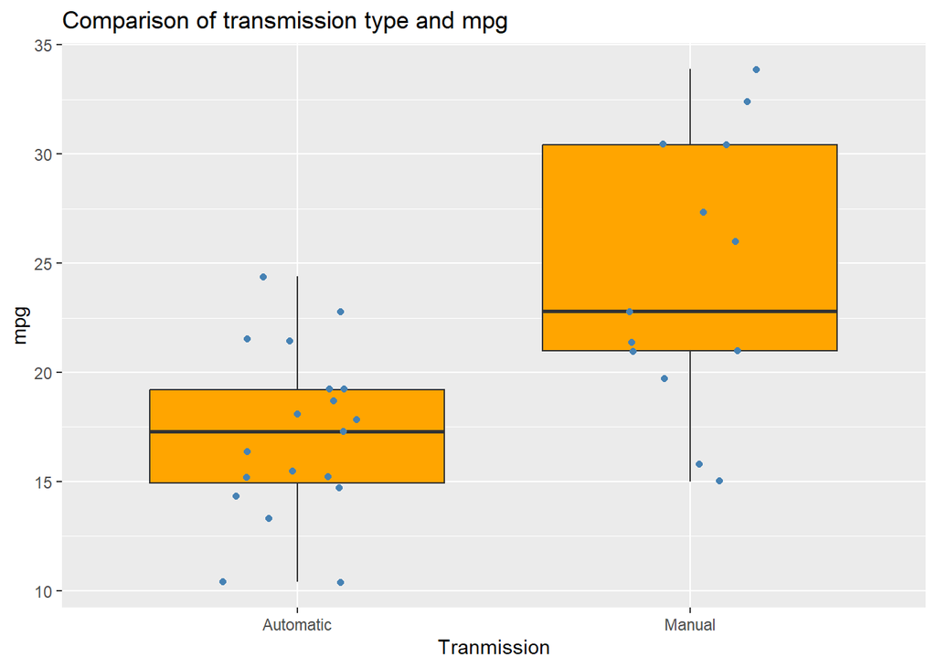

To avoid this confusion, we can modify the y-axis to “Miles per gallon (mpg)” for clarification. We can also add a subtitle that says “Higher mpg is better” to tell the audience that cars with higher miles per gallon are more preferred and have better fuel economy.

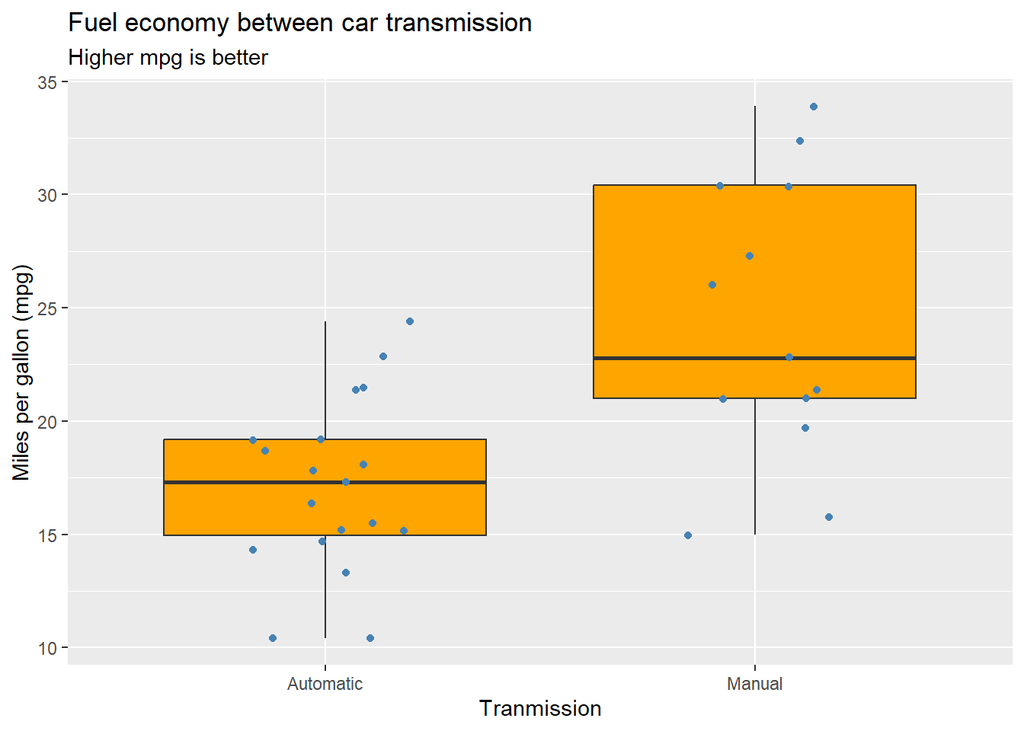

## Know When to Include Zero

Sometimes, you need to include zero in the axis in your visual. And other times, you do not. It depends on whether we are using length or position as the visual cues in the graph. It can be misinformative to not include zero in some cases.

Consider the bar plot below, which shows the life expectancy between Indonesia, Malaysia and Singapore for the year 2007. Notice how much the difference is between Indonesia and Singapore. Readers looking at this visual may make the conclusion that the life expectancy in Indonesia is much worse compared to Singapore. But look at the y-axis. It starts around 70 years and ends around 80 years, and it does not include zero in the axis.

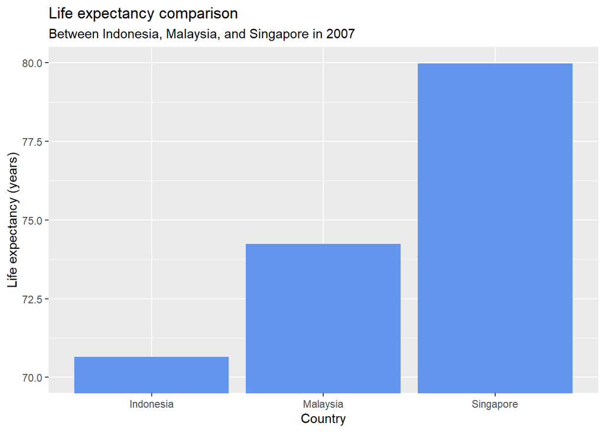

Now consider the same data and visual as before, but the y-axis is shown from zero to 80 years. Notice how the large difference between Indonesia and Singapore in the previous visual now seems less important.

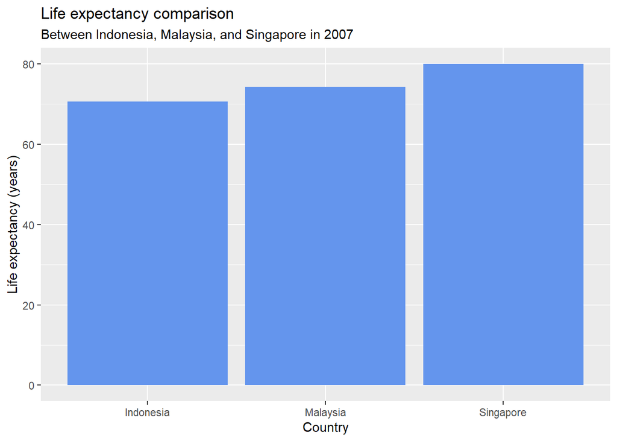

The bar plot uses length of the bar as the visual cue. Thus, it is important to include zero when using bar plot. Otherwise, the visual can lead to false conclusion.

[figure not shown]

## Show The Data

Our next advice is to show the data. This sounds obvious. After all, visuals are created to display the data. However, not all data should be displayed and chart creators have to decide on how much data should be shown in the visual, and how it should be displayed.

Consider the line chart below which shows the life expectancy across countries in Asia. The chart is too messy, as there are too many countries shown. When building visual, you should ask, what is it that you want to show to the audience, and how can you make it easy for them to read it.

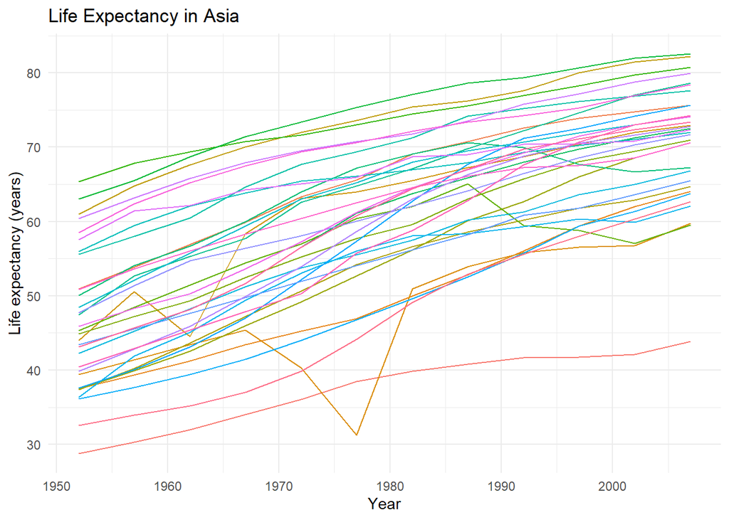

If the focus of the discussion is for the whole Asian countries, perhaps using line chart as above is not helpful. If you simply want to show the increasing trend of life expectancies, you can use scatter plot or box plot to simplify the chart.

However, if the discussion focuses on few selected countries, we can highlight the selected countries as shown in the line chart below. By highlighting countries, we help readers to focus their attention to the selected countries only, and reduce their focus to the grey lines, which are not as important as the colored ones.

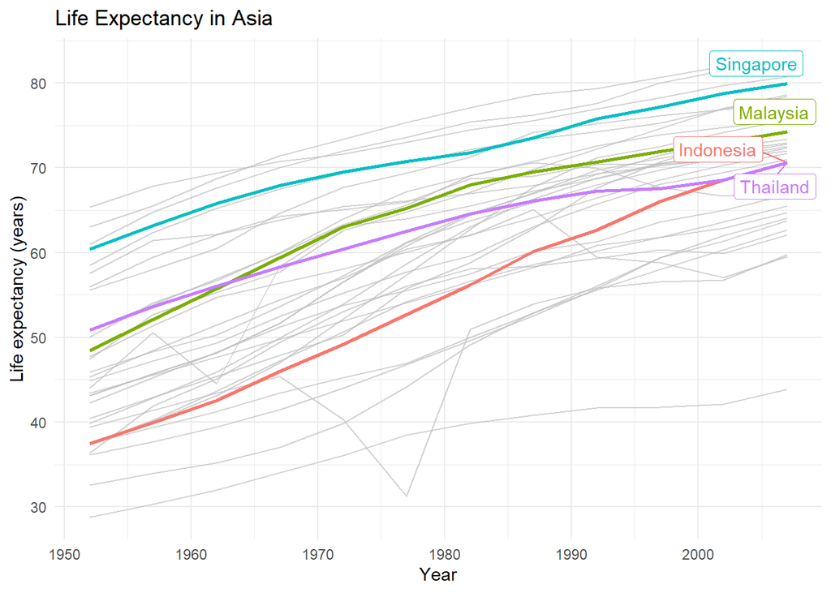

## Avoid Clutter

Another good advice when designing visuals to display data is to avoid and reduce clutter. What do we mean by clutter here? They are also called [chart junk](https://en.wikipedia.org/wiki/Chartjunk) which are visual elements included in charts or graphs that are unnecessary and are not needed to understand the information represented by the chart. Clutter only distract the readers from the important information.

Consider the bar chart presented below, which gives the average years of schooling between Germany and United States for 1997, 2007, and 2017. Does it look good to your eye? The use of pseudo-3D chart, the confusing y-axis ticks and labels, and the stripes make it too busy for the eye. They make reading the chart difficult, and may lead to a wrong conclusion.

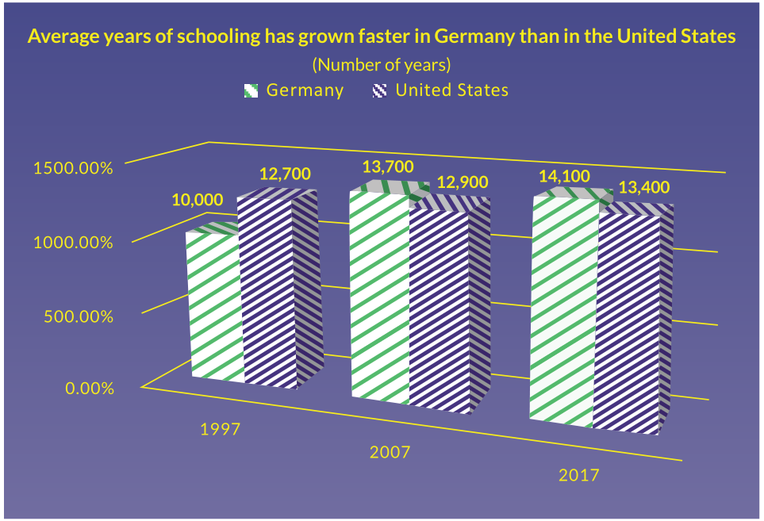

Source: Better Data Visualizations by Jonathan Schwabish (2021)

Now consider the bar chart below that uses the exact same data as above. But in this case, we remove the y-axis, improve readability of the data labels, make it a regular 2D bar chart, and use flat colors for the bars. These changes make the chart more easier to understand.

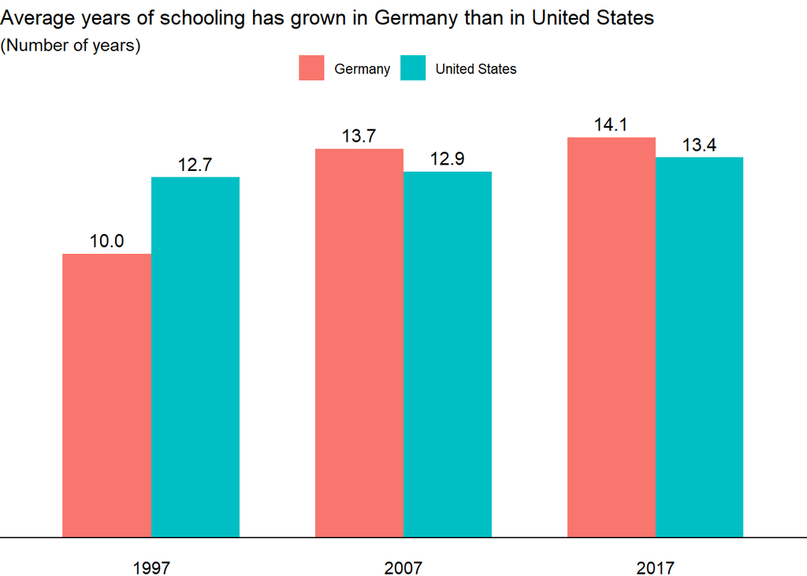

## Integrate Graphics with Text

In many cases, producing the basic visual is enough to display the data. However, we can further improve charts readability by integrating graphics with text. This include labeling the data directly without using legends, using suitable title, subtitle, and caption, as well as adding texts to explain the data on the chart.

In the bar chart below, we remove the legends for the color of the countries. But to help readers identify which color is for which county, we change the colors of the country in the title accordingly.

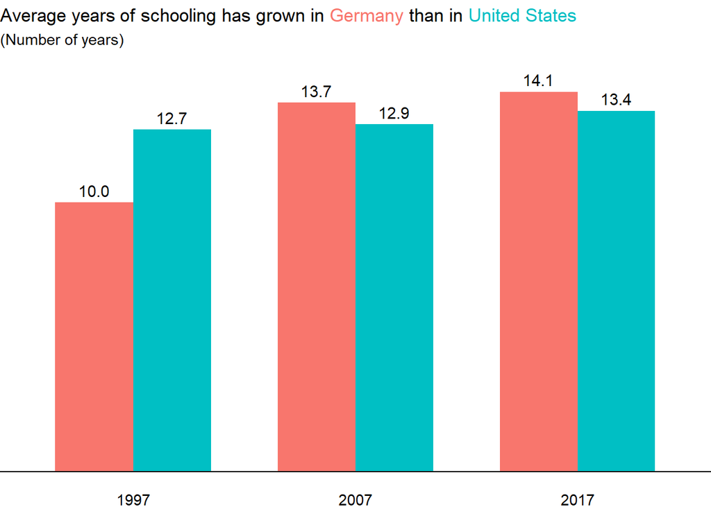

And in the line chart below, the unemployment rate in Malaysia from 2019 to 2023 is shown and we would like to show the effect of COVID-19 pandemic to the unemployment rate. To highlight the COVID-19 effects, we change the background colors for the selected time period, and add texts to explain the graph.

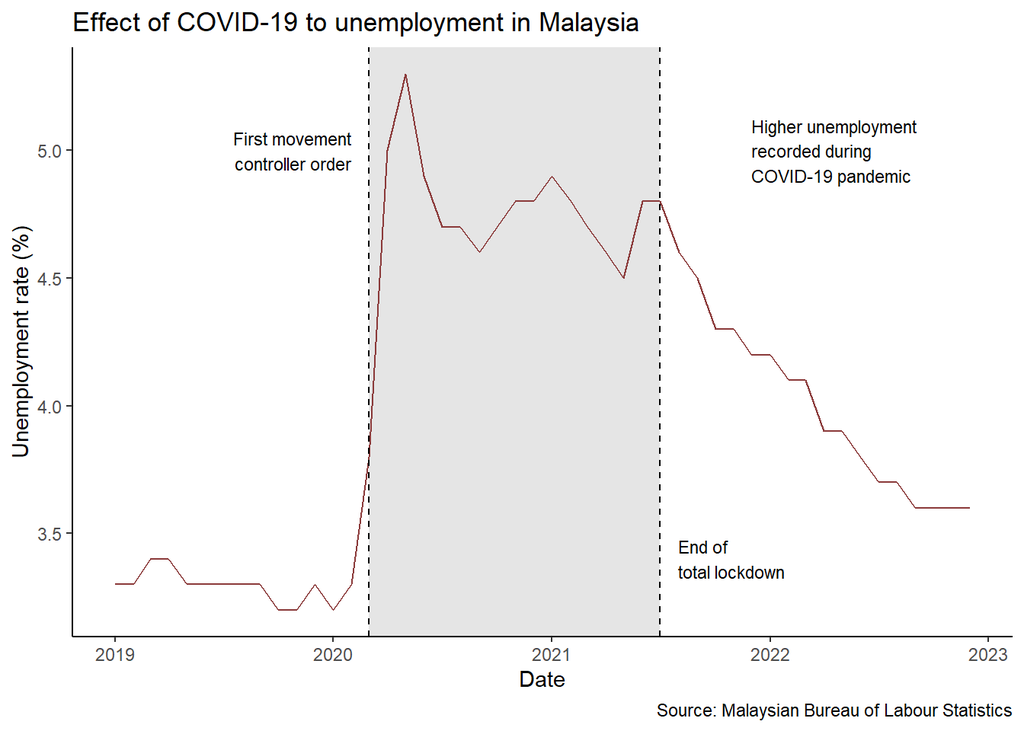

## Use Colors but Sparingly

Colors are definitely useful in data visualization. You can use it to draw your audience’s attention and makes your visual more pleasing. However, not all color usage is the same. Colors used should be intentional.

Typically, colors chosen for visuals depend on the color palette for the organization. For example, if we were to create visuals that display the current performance for Universiti Malaysia Terengganu (UMT), we would use purple, red, orange, white, or grey colors. This follows the typical color used by the university, similar to its logo.

[figure not shown]

UMT logo

When choosing colors, think about the meaning of the color used and the context of the data. For example, if you were to display data regarding water companies, do not use brown color as brown is associated with dirty or murky water. That is unless you want to display data on water pollution.

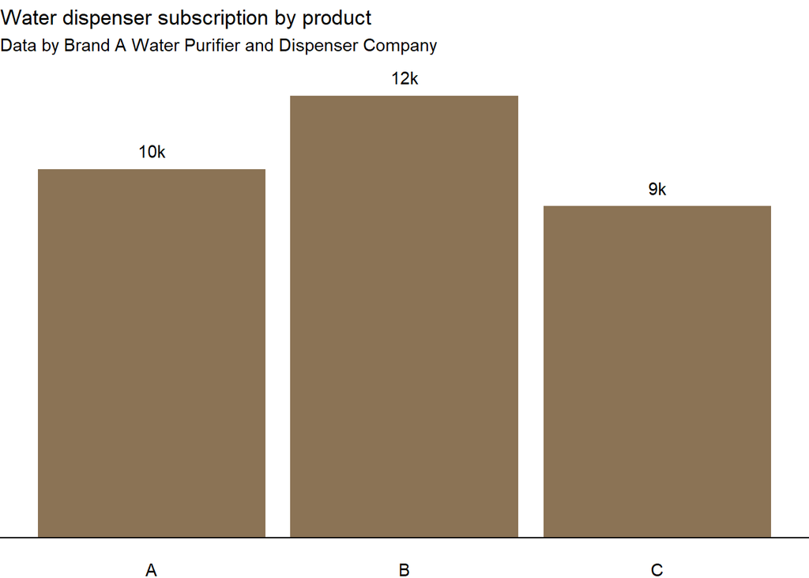

Water dispenser data and using brown color

We must also avoid cluttering the visual by overloading the viewers with using too much colors. For it to be effective, colors must be used sparingly with sufficient contrast. In the image below, the table on the left uses rainbow colors and it is hard to read what the visual is trying to tell the viewers. On the right, with only a single color with different contrast, we can see the drug rankings by country more easily.

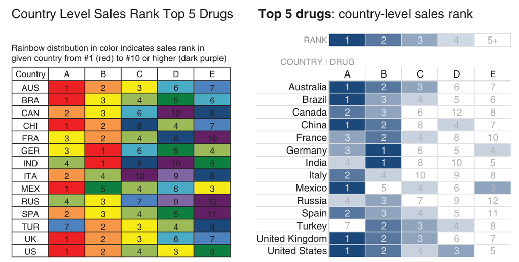

Avoid using too much variety in colors. Source: Storytelling with Data by Cole Nussbaumer Knaflic (2015)

Another important thing to note is to use colors consistently. This means using the same color palette and the same color throughout different plots and figures which helps with the viewers when reading different figures.

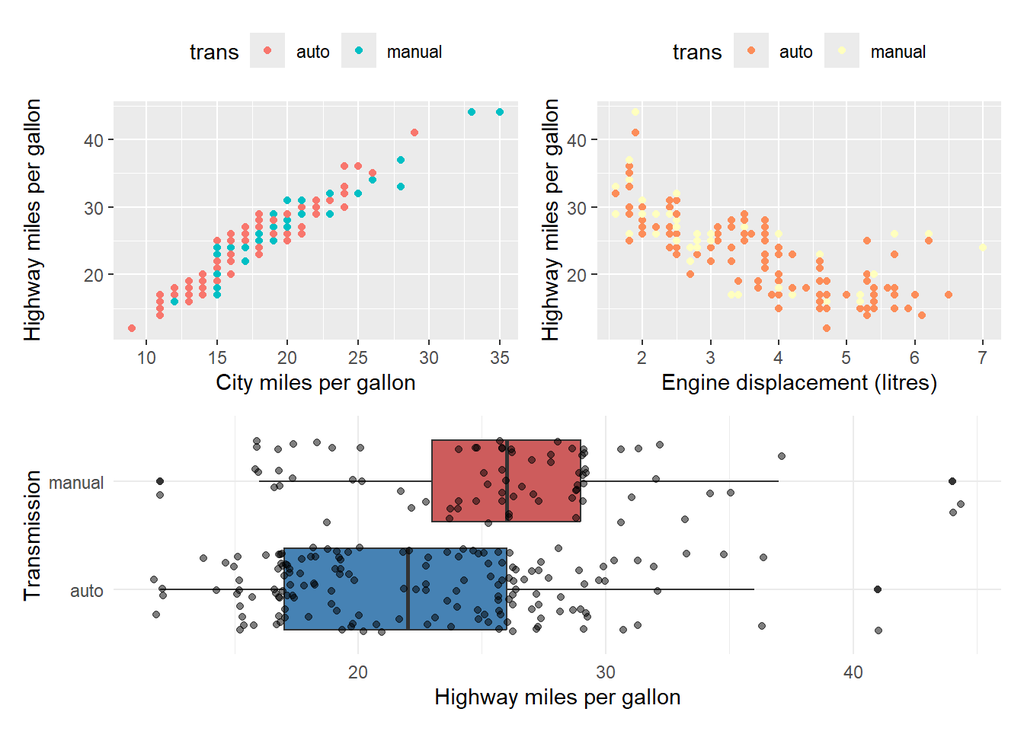

Bad usage of colors due to inconsistency

## Ease Comparisons

When visuals are used to make comparison, try to ease them. This can be done for example by using wider color scale, adding grid lines, avoiding area or volume visual cues, or using consistent group colors over multiple figures.

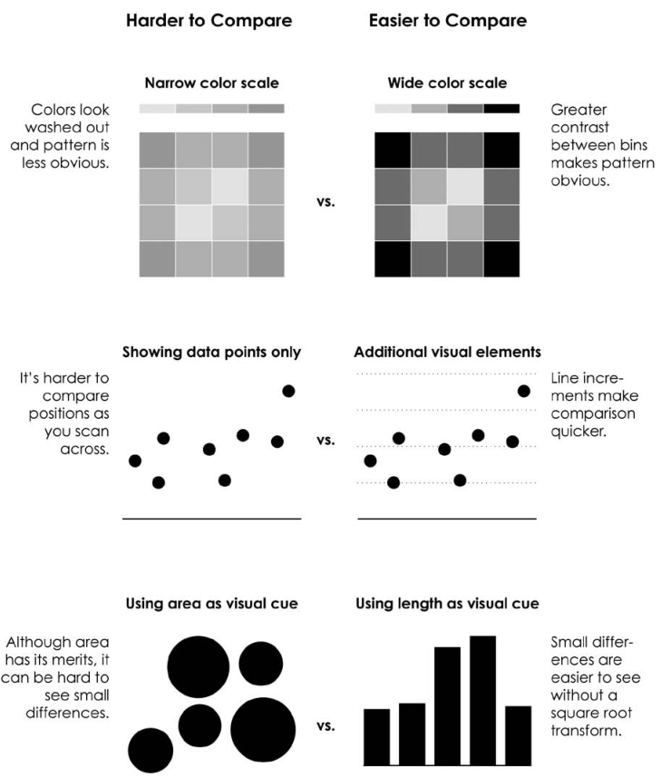

Help the viewers to make comparisons. Source: Data Points: Visualization That Means Something by Nathan Yau (2013)

[figure not shown]

## Be Wary of Spurious Correlation

Sometimes, data can be used to make a wrong conclusion. This has been used extensively by the media or politician to fit their narrative. One such example of this data dredging (or data snooping) is the spurious correlation.

In spurious correlation, we have two variables that seemingly related due to their high correlation. The *p*-value obtained from the hypothesis test for the significance of the correlation is also low, indicating that the two variables are correlated significantly.

Thus, one may make the conclusion that the two variables are related, or one variable causes another. But this is not always true. There is a golden rule in statistics - ‘Correlation does not imply causation’.

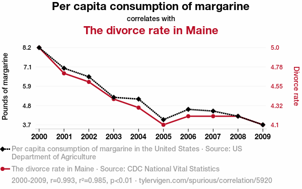

Is margarine consumption related to divorce?

Statisticians and data analysts have to be careful when making such conclusion. In this case, the two variables are not related as their relationship does not make sense. There are several possible reason for this situation.

1. There’s a third, confounding variable that needs to be considered in the relationship between the variables.
2. There is sampling bias where samples do not represent the population.
3. The high correlation is purely coincidental.

In the margarine consumption versus divorce rate, the more likely explanation is the existing of confounding variables, which are the economic factors that allow households to buy margarine and financial stability. For a given year, the higher the ability to buy margarine (or the better economy), the higher the divorce rate is.

## Conclusion

In this topic, we have given some advice and best practice that you can apply when making data visualization. Note however that the advice given is is not exhaustive as there are many and much more advice not included in this topic. You are encouraged to read more on this from books or from the internet. As you design your visual, you should think a little bit on what should or should not be included in the graph.